# from raw to identification

Xiaodong Feng

02 February, 2023

# 1 Introduction

This document contains basic steps of processing LC-MS datasets. This workflow aims to improve the identification part in LC-MS-based metabolomics.

# 2 Load required packages and functions

The user needs to change the directory accordingly

```r
source("d:/github/DynamicTol/vignettes/Alternative way to use the package.R")
```

# 3 Peak picking of Pure internal standards in LTQ Orbitrap XL based on the xcms package

## 3.1 Import data

In this example, we use the pure internal standards containing 15 internal standards, which was generated by LTQ Orbitrap XL, see details in the R package of *RMassBankData*. The .raw dataset were converted into .mzML format using the msconvert package, with the centroid method selected. The .mzML format dataset were then be loaded into XCMS using readMSData command.

```r
## Get the full path to the .mzml files
Mzml <- dir(system.file("spectra", package = "RMassBankData"),
            full.names = TRUE, recursive = TRUE)
BaseName <- sub(basename(Mzml),pattern = ".mzML",replacement = "", fixed = TRUE)
pd <- data.frame(
  sample_name = BaseName ,
  sample_group = BaseName, stringsAsFactors = FALSE
)
onDisk <- readMSData(files = Mzml, pdata = new("NAnnotatedDataFrame", pd), mode = "onDisk")
head(fData(onDisk))
```

```
##           fileIdx spIdx smoothed seqNum acquisitionNum msLevel polarity
## F01.S0001       1     1       NA      1              1       1        1
## F01.S0002       1     2       NA      2              2       2        1
## F01.S0003       1     3       NA      3              3       2        1
## F01.S0004       1     4       NA      4              4       2        1
## F01.S0005       1     5       NA      5              5       2        1
## F01.S0006       1     6       NA      6              6       2        1
##           originalPeaksCount totIonCurrent retentionTime basePeakMZ
## F01.S0001                374     3984215.0        0.7900  162.99141
## F01.S0002                 21      296013.8        1.6634   84.95910
## F01.S0003                 18      177569.2        2.0936   84.95910
## F01.S0004                 20      157048.2        2.5405   84.95918
## F01.S0005                 18      162584.9        2.9886   84.95910
## F01.S0006                 15      142860.2        3.4350   84.95911
##           basePeakIntensity collisionEnergy ionisationEnergy     lowMZ   highMZ
## F01.S0001          481971.1              NA                0 115.57957 977.3805
## F01.S0002          117441.5              35                0  52.34448 169.4646
## F01.S0003          113840.6              15                0  55.49028 163.0751
## F01.S0004          111010.8              30                0  50.10954 158.2217
## F01.S0005          121528.0              45                0  54.57306 173.0027
## F01.S0006          108954.8              60                0  54.01235 166.1025
##           precursorScanNum precursorMZ precursorCharge precursorIntensity
## F01.S0001               NA          NA              NA                 NA
## F01.S0002                1      162.99               0           481971.1
## F01.S0003                1      162.99               0           481971.1
## F01.S0004                1      162.99               0           481971.1
## F01.S0005                1      162.99               0           481971.1
## F01.S0006                1      162.99               0           481971.1
##           mergedScan mergedResultScanNum mergedResultStartScanNum
## F01.S0001         NA                  NA                       NA
## F01.S0002         NA                  NA                       NA
## F01.S0003         NA                  NA                       NA
## F01.S0004         NA                  NA                       NA
## F01.S0005         NA                  NA                       NA
## F01.S0006         NA                  NA                       NA
##           mergedResultEndScanNum injectionTime
## F01.S0001                     NA           200
## F01.S0002                     NA           200
## F01.S0003                     NA           200
## F01.S0004                     NA           200
```

[output cut: 22 more lines]

```
## F01.S0006                   NA                  162.99
##           isolationWindowLowerOffset isolationWindowUpperOffset
## F01.S0001                         NA                         NA
## F01.S0002                       0.75                       0.75
## F01.S0003                       0.75                       0.75
## F01.S0004                       0.75                       0.75
## F01.S0005                       0.75                       0.75
## F01.S0006                       0.75                       0.75
##           scanWindowLowerLimit scanWindowUpperLimit spectrum
## F01.S0001                  115                 1000        1
## F01.S0002                   50                  175        2
## F01.S0003                   50                  175        3
## F01.S0004                   50                  175        4
## F01.S0005                   50                  175        5
## F01.S0006                   50                  175        6
```

```r
table(msLevel(onDisk))
```

```
##
##     1     2
##  3600 38626
```

# 4 Peak detection

In this example, we perform the peak detection using XCMS’s Centwave aligorithm. The parameters used in peak detection are important. The user need to adjust these parameters according to their own dataset. Here we perform the dynamic binning peak detection as described in *X. Feng, W. Zhang, F. Kuipers, I. Kema, A. Barcaru, P. Horvatovich, Dynamic binning peak detection and assessment of various lipidomics liquid chromatography-mass spectrometry pre-processing platforms suppl. Anal. Chim. Acta. 31, 1–17 (2021)* We first need to calculate the proper constant A according to mass resoving power and reference m/z. The specificities are based on *https://biotech.ufl.edu/portfolio/ltq-orbitrap-xl-system/*

```r
MRP <- 60000; MRPValue <- 60000;#
RefMZ <- 400; RefMZValue <- 400; #  Velos is mz reference 400 while Q-Exactive is 200.
AValue <- 1 / (MRP * (RefMZ^0.5) * 2.35482)
print(AValue)
```

```
## [1] 3.538841e-07
```

```r
cwp <- CentWaveParam(
  A = AValue, ppm = 3, Instrument = 2,
  peakwidth = c(2.4, 30), snthresh = 5, noise = 100000, prefilter = c(1, 200000),
  firstBaselineCheck = FALSE, integrate = 2
)
xdata <- xcms::findChromPeaks(onDisk, param = cwp)
head(chromPeaks(xdata))
```

```
##             mz    mzmin    mzmax       rt    rtmin     rtmax      into
## CP001 198.0877 198.0875 198.0878 316.8093 296.2694  340.5593  11764528
## CP002 199.0815 199.0813 199.0816 310.7193 296.2694  364.8793  40435643
## CP003 197.0846 197.0843 197.0847 310.7193 296.2694  429.7999 139912351
## CP004 223.0969 223.0968 223.0970 543.4594 511.0798  584.0199  17878148
## CP005 130.9650 130.9649 130.9650  42.1599   0.7900   74.8693  27505157
## CP006 337.0756 337.0755 337.0757 837.8794 821.3294 1042.9793  43373489
##            intb      maxo     sn sample
## CP001  11764491  760856.2 760855      1
## CP002  39806402 2328466.8    137      1
## CP003 136208329 7330521.5    188      1
## CP004  16011778  750063.5     22      1
## CP005  20214623  741967.8    151      1
## CP006  42039036  584995.5     84      1
```

Let’s check the results after peak detection, the selected retention time of 222 seconds and m/z value of 136.1121 Da is based on the value of Amphetamine

```r
rtSel <- 222
mzSel <- 136.1121
pks <- data.frame(peak_id = rownames(chromPeaks(xdata)), chromPeaks(xdata))
pks_DT <- data.table::data.table(pks)
pks_DT[abs(mz-mzSel) < 0.02 & abs(rt-rtSel) < 10]
```

```
##    peak_id       mz    mzmin    mzmax      rt   rtmin   rtmax      into
## 1:   CP068 136.1121 136.1118 136.1122 217.225 196.535 338.665 193264249
##         intb    maxo  sn sample
## 1: 188952043 9770504 293      5
```

# 5 MS1 Peak annotations based on the MetaboAnnotation package

At this step we aim to annote the MS1 peak based on the the Internal standards information described in the *RMassBankData*. Thus, the std_ions.txt contains the information of the 15 internal standards accordingly. Especially the retention time, which is critical for accurate identification. However, there are limited retention time records in the publice database. It is also worth to stress that the output collumns of ‘score’ and ‘score_rt” are ’mass difference in Da’ and ‘retention time difference’, respectively. To avoid confusion, we changed the names accordingly. Notice, the user needs to change the dir according to where the package is located.

```r
std_ions <- read.table("d:/github/DynamicTol/input/txt/std_ions.txt",
                       sep = "\t", header = TRUE)
head(std_ions)
```

```
##   compound_id ion_adduct ion_rt   ion_mz exactmass
## 1        2822     [M+H]+  222.0 136.1121  135.1048
## 2        2829     [M+H]+  231.0 150.1277  149.1204
## 3        2758     [M+H]+  181.8 166.1227  165.1154
## 4        2820     [M+H]+   79.8 177.1386  176.1313
## 5        2827     [M+H]+  267.0 178.1227  177.1154
## 6        2818     [M+H]+  315.0 197.0840  196.0767
##                                 Name                    INCHIKEY    FORMULA
## 1                        Amphetamine KWTSXDURSIMDCE-UHFFFAOYSA-N     C9H13N
## 2                    Methamphetamine MYWUZJCMWCOHBA-VIFPVBQESA-N    C10H15N
## 3                          Ephedrine KWGRBVOPPLSCSI-WPRPVWTQSA-N   C10H15NO
## 4                 1-Benzylpiperazine IQXXEPZFOOTTBA-UHFFFAOYSA-N   C11H16N2
## 5 Mephedrone (4-Methylmethcathinone) YELGFTGWJGBAQU-UHFFFAOYSA-N   C11H15NO
## 6       1-(3-Chlorophenyl)piperazine VHFVKMTVMIZMIK-UHFFFAOYSA-N C10H13ClN2
##                          SMILES CHEMSPIDER      PUBCHEM          CAS
## 1              c1(ccccc1)CC(N)C   13852819     CID:3007     300-62-9
## 2         c1cccc(c1)C[C@H](C)NC      10379    CID:10836     537-46-2
## 3 c1([C@H]([C@@H](NC)C)O)ccccc1       8935     CID:9294     299-42-3
## 4           C1CN(CCN1)Cc1ccccc1      68493    CID:75994    2759-28-6
## 5        Cc1ccc(cc1)C(=O)C(C)NC   21485694 CID:45266826 1189805-46-6
## 6          c1c(Cl)cccc1N1CCNCC1       1314     CID:1355    6640-24-0
```

```r
parm <- MetaboAnnotation::Mass2MzRtParam(adducts = c("[M+H]+", "[M+Na]+", "[M+K]+"),toleranceRt = 10)
pks_match <- MetaboAnnotation::matchValues(pks, std_ions, parm,rtColname = c("rt", "ion_rt"))
pks_match
```

```
## Object of class Matched
## Total number of matches: 15
## Number of query objects: 279 (15 matched)
## Number of target objects: 15 (15 matched)
```

```r
pks_match_DT <- as.data.table(MetaboAnnotation::matchedData(pks_match, colnames(pks_match)))
head(pks_match_DT)
```

```
##    peak_id       mz    mzmin    mzmax       rt    rtmin     rtmax      into
## 1:   CP001 198.0877 198.0875 198.0878 316.8093 296.2694  340.5593  11764528
## 2:   CP002 199.0815 199.0813 199.0816 310.7193 296.2694  364.8793  40435643
## 3:   CP003 197.0846 197.0843 197.0847 310.7193 296.2694  429.7999 139912351
## 4:   CP004 223.0969 223.0968 223.0970 543.4594 511.0798  584.0199  17878148
## 5:   CP005 130.9650 130.9649 130.9650  42.1599   0.7900   74.8693  27505157
## 6:   CP006 337.0756 337.0755 337.0757 837.8794 821.3294 1042.9793  43373489
##         intb      maxo     sn sample target_compound_id target_ion_adduct
## 1:  11764491  760856.2 760855      1                 NA              <NA>
## 2:  39806402 2328466.8    137      1                 NA              <NA>
## 3: 136208329 7330521.5    188      1               2818            [M+H]+
## 4:  16011778  750063.5     22      1                 NA              <NA>
## 5:  20214623  741967.8    151      1                 NA              <NA>
## 6:  42039036  584995.5     84      1                 NA              <NA>
##    target_ion_rt target_ion_mz target_exactmass                  target_Name
```

[output cut: 27 more lines]

```r
names(pks_match_DT)
```

```
##  [1] "peak_id"            "mz"                 "mzmin"
##  [4] "mzmax"              "rt"                 "rtmin"
##  [7] "rtmax"              "into"               "intb"
## [10] "maxo"               "sn"                 "sample"
## [13] "target_compound_id" "target_ion_adduct"  "target_ion_rt"
## [16] "target_ion_mz"      "target_exactmass"   "target_Name"
## [19] "target_INCHIKEY"    "target_FORMULA"     "target_SMILES"
## [22] "target_CHEMSPIDER"  "target_PUBCHEM"     "target_CAS"
## [25] "adduct"             "score"              "ppm_error"
## [28] "score_rt"
```

```r
setnames(pks_match_DT,c('score','score_rt'),c('da_error','rt_error'))
names(pks_match_DT)
```

```
##  [1] "peak_id"            "mz"                 "mzmin"
##  [4] "mzmax"              "rt"                 "rtmin"
##  [7] "rtmax"              "into"               "intb"
## [10] "maxo"               "sn"                 "sample"
## [13] "target_compound_id" "target_ion_adduct"  "target_ion_rt"
## [16] "target_ion_mz"      "target_exactmass"   "target_Name"
## [19] "target_INCHIKEY"    "target_FORMULA"     "target_SMILES"
## [22] "target_CHEMSPIDER"  "target_PUBCHEM"     "target_CAS"
## [25] "adduct"             "da_error"           "ppm_error"
## [28] "rt_error"
```

# 6 MS2 peaks export based on the Spectra package

As we want to calculate the MS2 similarity, we have to export the MS2 peaks here we use the functions from the *Spectra* package. In detail, we export the related MS2 according to the index in MS1. Some detected MS1 may not contain the related MSMS, we exclude them in this step.

```r
dda_spectra <- chromPeakSpectra(xdata, return.type = "Spectra", peaks = pks_match$peak_id)
dda_spectra
```

```
## MSn data (Spectra) with 1470 spectra in a MsBackendMzR backend:
##             msLevel     rtime scanIndex
##           <integer> <numeric> <integer>
## F01.S1549         2   838.884      1549
## F01.S1550         2   839.447      1550
## F01.S1551         2   839.888      1551
## F01.S1552         2   840.329      1552
## F01.S1553         2   840.772      1553
## ...             ...       ...       ...
## F15.S2204         2   1211.39      2204
## F15.S2205         2   1211.93      2205
## F15.S2206         2   1212.47      2206
## F15.S2207         2   1212.96      2207
## F15.S2208         2   1213.64      2208
##  ... 38 more variables/columns.
##
## file(s):
## 1_3_Chlorophenyl_piperazin_2818_pos.mzML
## 1_3_Trifluoromethylphenyl_piperazin_2819_pos.mzML
## 1_Benzylpiperazin_2820_pos.mzML
##  ... 12 more files
```

```r
unique(dda_spectra$peak_id)
```

```
##  [1] "CP006" "CP013" "CP028" "CP042" "CP044" "CP057" "CP068" "CP103" "CP112"
## [10] "CP117" "CP127" "CP133" "CP163" "CP172" "CP190" "CP198" "CP205" "CP208"
## [19] "CP215" "CP228" "CP241" "CP253" "CP261" "CP267" "CP269" "CP274"
```

```r
register(SerialParam()) # disable paralell
## Merge the spectra to obtain the consensus spectrum
dda_spectrum <- Spectra::combineSpectra(dda_spectra, FUN = combinePeaks, ppm = 20,
                              peaks = "intersect", minProp = 0.8,
                              intensityFun = median, mzFun = median,
                              f = dda_spectra$peak_id)
dda_spectrum
```

```
## MSn data (Spectra) with 26 spectra in a MsBackendDataFrame backend:
##             msLevel     rtime scanIndex
##           <integer> <numeric> <integer>
## F01.S1549         2  838.8839      1549
## F01.S2269         2 1232.8038      2269
## F02.S0647         2  350.5063       647
## F02.S2254         2 1215.1863      2254
## F03.S0137         2   74.5043       137
## ...             ...       ...       ...
## F14.S0392         2   216.992       392
## F14.S2147         2  1171.393      2147
## F15.S0317         2   173.209       317
## F15.S1593         2   875.858      1593
## F15.S1999         2  1099.648      1999
##  ... 38 more variables/columns.
## Processing:
##  Switch backend from MsBackendMzR to MsBackendDataFrame [Thu Feb 02 22:39:02 2023]
##  Switch backend from MsBackendMzR to MsBackendDataFrame [Thu Feb 02 22:39:03 2023]
##  Switch backend from MsBackendMzR to MsBackendDataFrame [Thu Feb 02 22:39:04 2023]
##  ...1 more processings. Use 'processingLog' to list all.
```

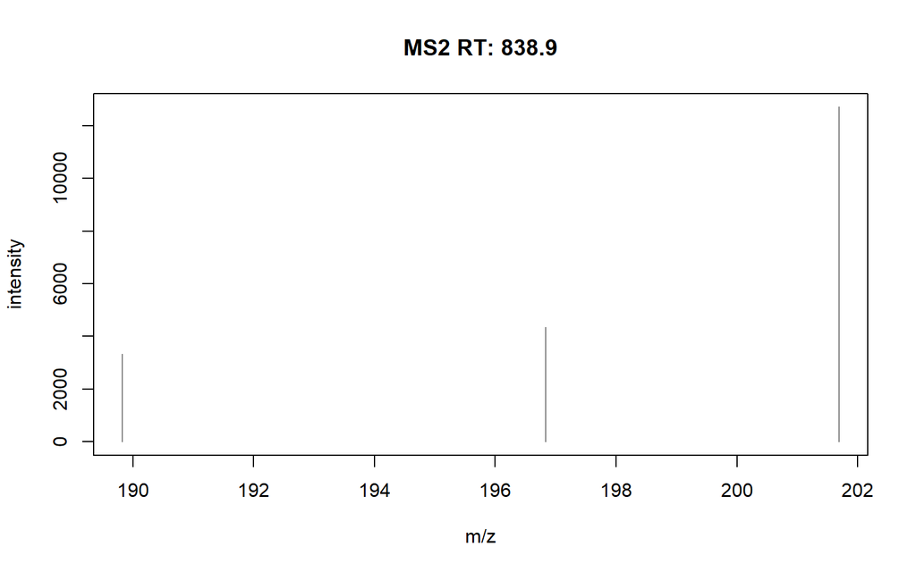

```r
## Normalization to 100 according to maximum
Spectra::plotSpectra(dda_spectrum[1]) # before normalization
```

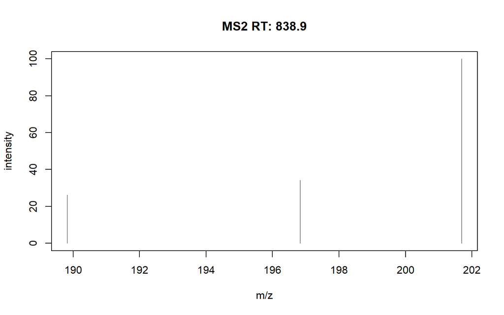

```r
dda_spectrum <- addProcessing(dda_spectrum, FUN = norm_fun)
Spectra::plotSpectra(dda_spectrum[1]) # after normalization
```

```r
## Extract the MS2 peaks
dda_spectrum_peaks <- peaksData(dda_spectrum)
dda_spectrum_peaks[[1]]
```

```
##            mz intensity
## [1,] 189.8238  26.17625
## [2,] 196.8306  34.18969
## [3,] 201.6906 100.00000
```

```r
## Combine the peaks and add the meta id
peaks.rbind <- data.table()
for (id in c(1:length(dda_spectrum_peaks))) {
  # print(id)
  peak <- data.table(dda_spectrum_peaks[[id]]) %>% .[,library_spectra_meta_id:=id]
  peaks.rbind <- rbind(peaks.rbind, peak)
}
setnames(peaks.rbind, 'intensity', 'i')
dda_spectrum_DT <- as.data.table(spectraData(dda_spectrum))
```

# 7 Creat query.sqlite database

Current workflow supports the library search based on the .sqlite database files, Thus we need to transfer the results from previous steps into the .sqlite formats.

```r
con_q <- DBI::dbConnect(RSQLite::SQLite(),'d:/github/DynamicTol/input/sqlite/Narcotics.sqlite')
## library_spectra_meta
spectra_meta_q <- left_join(dda_spectrum_DT,pks_match_DT,by= 'peak_id') %>%
  cbind(.,id=c(1:nrow(.)))
names(spectra_meta_q)
```

```
##  [1] "msLevel"                  "rtime"
##  [3] "acquisitionNum"           "scanIndex"
##  [5] "dataStorage"              "dataOrigin"
##  [7] "centroided"               "smoothed"
##  [9] "polarity"                 "precScanNum"
## [11] "precursorMz"              "precursorIntensity"
## [13] "precursorCharge"          "collisionEnergy"
## [15] "isolationWindowLowerMz"   "isolationWindowTargetMz"
## [17] "isolationWindowUpperMz"   "fromFile"
## [19] "spIdx"                    "originalPeaksCount"
## [21] "totIonCurrent"            "basePeakMZ"
## [23] "basePeakIntensity"        "ionisationEnergy"
## [25] "lowMZ"                    "highMZ"
## [27] "mergedScan"               "mergedResultScanNum"
## [29] "mergedResultStartScanNum" "mergedResultEndScanNum"
```

[output cut: 19 more lines]

```r
setnames(
  spectra_meta_q, c("precursorMz", "rtime", "target_Name", "collisionEnergy", "target_compound_id", "target_ion_adduct", "target_INCHIKEY", "target_SMILES"),
  c("precursor_mz", "retention_time", "name", "collision_energy", "accession", "precursor_type", "inchikey_id", "smiles")
)
names(spectra_meta_q)
```

```
##  [1] "msLevel"                  "retention_time"
##  [3] "acquisitionNum"           "scanIndex"
##  [5] "dataStorage"              "dataOrigin"
##  [7] "centroided"               "smoothed"
##  [9] "polarity"                 "precScanNum"
## [11] "precursor_mz"             "precursorIntensity"
## [13] "precursorCharge"          "collision_energy"
## [15] "isolationWindowLowerMz"   "isolationWindowTargetMz"
## [17] "isolationWindowUpperMz"   "fromFile"
## [19] "spIdx"                    "originalPeaksCount"
## [21] "totIonCurrent"            "basePeakMZ"
## [23] "basePeakIntensity"        "ionisationEnergy"
## [25] "lowMZ"                    "highMZ"
## [27] "mergedScan"               "mergedResultScanNum"
## [29] "mergedResultStartScanNum" "mergedResultEndScanNum"
```

[output cut: 19 more lines]

```r
DBI::dbWriteTable(con_q, name='library_spectra_meta', value=spectra_meta_q, overwrite=TRUE) # we need to stick to this name of library_spectra_meta, otherwise will get error
## library_spectra
DBI::dbWriteTable(con_q, name='library_spectra', value=peaks.rbind, overwrite=TRUE)
```

# 8 Creat library .sqlite database

To perform the spectral matching, we first need to prepare the library. Here we downloaded the library from [msp2db](https://github.com/computational-metabolomics/msp2db/releases/tag/v0.0.14-mona-23042021), which includes the database created by parsing all of the available MoNA MSP files as of 23/04/2021. As the example dataset is in positive mode, so here we only use the positive library with the parameter *l_accessionsValue*. As the database is quite large, thus it is not included in the package, the user needs to download the database by themselves and change the working dir accordingly.

```r
l_dbPthValue <- "d:/github/DynamicTol/input/sqlite/20210423_mona.sqlite"
con <- DBI::dbConnect(RSQLite::SQLite(), l_dbPthValue)
library_spectra_meta <- con %>%
  dplyr::tbl("library_spectra_meta") %>%
  dplyr::collect() %>%
  as.data.table(.)
## Create the library accessions, to reduce the library
unique(library_spectra_meta$instrument_type)
```

```
##  [1] "in-silico QTOF"
##  [2] "QTOF"
##  [3] NA
##  [4] "GC-MS"
##  [5] "Quattro_QQQ"
##  [6] "ESI-TOF"
##  [7] "EI-B"
##  [8] "GC-EI-TOF"
##  [9] "GC-EI-TOF (Pegasus III TOF-MS system, Leco; GC 6890, Agilent Technologies)"
## [10] "LC-ESI-IT"
## [11] "CI-B"
## [12] "FAB-EBEB (JMS-HX/HX 110A, JEOL)"
## [13] "Linear Ion Trap"
## [14] "LC-ESI-QIT"
## [15] "LC-ESI-QQ"
```

[output cut: 46 more lines]

```r
MetaPos <- library_spectra_meta[polarity == "positive" & ms_level == 2 &
  instrument_type %in% c("LC-ESI-ITFT", "LC-ESI-QFT", "ESI-QFT", NA)] # only use the orbitrap dataset
unique(MetaPos$instrument_type)
```

```
## [1] NA            "LC-ESI-ITFT" "LC-ESI-QFT"  "ESI-QFT"
```

```r
l_accessionsValue <- MetaPos$accession
l_accessionsValue[1]
```

```
## [1] "CCMSLIB00000071742"
```

```r
length(l_accessionsValue) # 48800
```

```
## [1] 48800
```

# 9 Search query .sqlite against library .sqlite

```r
tictoc::tic() # Starting time of search
Pth_Narcotics <- "d:/github/DynamicTol/input/sqlite/Narcotics.sqlite"
Pth_Mona <- "d:/github/DynamicTol/input/sqlite/20210423_mona.sqlite"
# for test begin
for (id in spectra_meta_q$id[4]) {
  SingleResult <- spectralMatching(q_dbPth = Pth_Narcotics, l_dbPth = Pth_Mona, l_accessions = l_accessionsValue, q_pids = id, mztol = NA)
}
```

```
## [1] "4 mztol NA libsch reverse decoy FALSE"
```

```r
SingleResult
```

```
##    dpc dpc.decoy dpc.xcorr Match Match.decoy library_rt library_accession
## 1:   0      <NA>      <NA>     0        <NA>       <NA> VF-NPL-QEHF006496
## 2:   0      <NA>      <NA>     0        <NA>       <NA> VF-NPL-QEHF006497
## 3:   0      <NA>      <NA>     0        <NA>       <NA> VF-NPL-QEHF006498
## 4:   0      <NA>      <NA>     0        <NA>       <NA> VF-NPL-QEHF006631
## 5:   0      <NA>      <NA>     0        <NA>       <NA> VF-NPL-QEHF006632
## 6:   0      <NA>      <NA>     0        <NA>       <NA> VF-NPL-QEHF006633
##    library_precursor_mz library_precursor_type
## 1:     413.268615722656                 [M+H]+
## 2:     413.268615722656                 [M+H]+
## 3:     413.268615722656                 [M+H]+
## 4:     413.268615722656                 [M+H]+
## 5:     413.268615722656                 [M+H]+
## 6:     413.268615722656                 [M+H]+
##                                                  library_entry_name
```

[output cut: 20 more lines]

```r
# for test end
tictoc::toc() # Ending time of search 64.3 sec elapsed
```

```
## 40.32 sec elapsed
```

We can then have a look of the matched results, among them * dpc - dot product cosine of the match * dpc.decoy - dot product cosine of the match calculated based on the decoy database * dpc.xcorr - cross correlation score of dpc * library_rt - retention time of library spectra * library_accession - library accession value (unique string or number given to either MoNA or Massbank data entires) * library_precursor_mz - library precursor mz * library_precursor_type - library precursor type (i.e. adduct) * library_entry_name - Name given to the library spectra * library_inchikey - inchikey of the matched library spectra * library_lpid - id in database of library spectra * query_qpid - id in database of query spectra * query_rt - retention time of query spectra * query_precursor_mz - query precursor mz * query_inchikey - inchikey of the query spectra